# GERMINACIÓN DE SEMILLAS DE TRIGO (*Triticum aestivum*) BAJO DIFERENTES NIVELES DE pH.

Author

Huanambal Galvez Jose Luis, Perez Campos Elda, Pizarro Zabaleta Nixon, Roman Peña Lleyner, Tomapasca Lopez Frank, Vega Chavez Gimena

# 1 INTRODUCCIÓN

El trigo (*Triticum aestivum*) es uno de los cultivos de mayor relevancia a nivel mundial, tanto por su valor nutricional como por su papel en la seguridad alimentaria. Su semilla posee características que la convierten en un modelo adecuado para estudios fisiológicos y de calidad, como una germinación rápida y una alta sensibilidad a factores ambientales (FAO, 2021). Entre estos factores, el pH del medio en el que germina la semilla es determinante, ya que puede influir directamente en la disponibilidad de nutrientes, la absorción de agua y el funcionamiento de las enzimas involucradas en el proceso germinativo (Kumar et al., 2021).

Por ejemplo, niveles de pH ácidos o alcalinos extremos pueden provocar un retraso en la emergencia de la radícula o una reducción en el porcentaje total de germinación (Bewley et al., 2013). Por ello, el presente experimento tiene como finalidad evaluar el efecto de diferentes niveles de pH (ácido, neutro y alcalino) sobre la germinación de semillas de trigo, midiendo indicadores clave como el porcentaje de germinación y tambien el tiempo promedio de germinación.

# 2 OBJETIVO

## 2.1 Objetivo general

Evaluar el efecto de diferentes niveles de pH (ácido, alcalino y neutro) en la germinación de semillas de trigo (*Triticum aestivum*).

## 2.2 Objetivos especificos

-Calcular el índice de velocidad de germinación de semillas de trigo en función del pH (ácido, neutro y alcalino).

-Evaluar el tiempo promedio de germinación de semillas de trigo bajo condiciones de pH ácido, alcalino y neutro.

-Determinar el porcentaje de germinación de semillas de (*Triticum aestivum*) sometidas a diferentes niveles de pH.

# 3 MATERIALES Y MÉTODOS

## 3.1 Materiales

-Semillas de trigo (*Triticum aestivum*) -Papel toalla. -Agua destilada. -Guantes. -Recipientes plásticos. -Bicarbonato de sodio. -Vinagre blanco. -Papel tornasol. -Etiquetas -Jeringa

[figure not shown]

## 3.2 Metodología

Variables evaluadas Variable independiente:  Método (pH ácido, alcalino y neutro) Variable dependiente:  Porcentaje de germinación de semillas  Índice de sincronización de la germinación de semillas.  Tiempo medio de germinación de semillas Diseño experimental Tratamientos: • Bloques: • BLOQUE I: pH ácido (4.5) • BLOQUE II: pH alcalino (9.5) • BLOQUE II: pH neutro (Control: 7.0) • Repeticiones: 5 repeticiones por bloque. • Número de semillas por repetición: 25 semillas por repetición. • Diseño estadístico: Diseño de Bloques Completos al Azar (DBCA).

Obtención de la semilla La semilla de trigo (Triticum aestivum) fue adquirida del mercado modelo del distrito de Chachapoyas, Amazonas. Elaboración de etiquetas Para identificar los tratamientos se elaboraron etiquetas en R con sus respectivas leyendas (pH alcalino, pH ácido y neutro) lo que va a facilitar un seguimiento organizado y preciso del comportamiento de cada grupo de semillas.

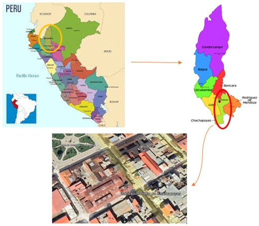

Selección de semillas Las semillas fueron seleccionadas cuidadosamente, asegurándose de que no presentarán defectos como daños por plagas o un tamaño excesivamente reducido. Preparación de los recipientes El experimento se desarrolló haciendo uso de 15 recipientes plásticos, de tal manera que están divididos en tres tratamientos: 5 recipientes con ph ácido (4.5), 5 recipientes PH alcalino (9.5) y 5 recipientes con pH neutro (7.0), además se usó una base de papel toalla Obtención de agua con pH alcalino Con el fin de obtener agua con un pH alcalino, se aplicó 8,4 gr de bicarbonato de sodio en 1 Lt de agua destilada, seguidamente se realizó el proceso de procesamiento térmico del bicarbonato de sodio (Cienciabit, 2019). Para verificar el grado de pH obtenido, se utilizan tiras de papel tornasol. Obtención de agua con pH ácido Se aplicó 0,5 ml de vinagre blanco al 4% en 1 Lt de agua destilada con el fin de acidificar la solución mediante neutralización química. Para verificar el grado de pH obtenido, se utilizaron tiras de papel tornasol. Remoje de granos Las semillas de trigo se remojarón en las soluciones de agua con distinto pH (ácido, alcalino y neutro) por el lapso de 9 horas.

Organización de las semillas Posteriormente se colocaron 25 semillas en cada unidad de repetición, y finalmente se procedió a colocar el etiquetado de identificación respectivo.

[figure not shown]

### 3.2.1 Análisis estadístico

```r
source("https://inkaverse.com/setup.r")
```

[output not shown]

[output not shown]

[output not shown]

[output not shown]

[output not shown]

[output not shown]

[output not shown]

[output not shown]

[output not shown]

```r
library(tidyverse)
library(GerminaR)
library(cowplot)
library(readxl)
```

### 3.2.2 Importar datos

```r
url <- "https://docs.google.com/spreadsheets/d/1TiGtx6m6G-7bgymVZVfVF-JA5JekxvarwcY2FETUon8/edit?usp=sharing"

gs <- as_sheets_id(url)

fb <- range_read(gs
                 , sheet = "fb") %>%
  mutate(across(tratamiento,  ~as.factor(.))) %>%
  as.data.frame()
str(fb)
## 'data.frame':    15 obs. of  11 variables:
##  $ plots      : num  101 102 103 104 105 106 107 108 109 110 ...
##  $ tratamiento: Factor w/ 3 levels "pH ácido","pH alcalino",..: 3 2 1 3 2 1 3 2 1 3 ...
##  $ seeds      : num  25 25 25 25 25 25 25 25 25 25 ...
##  $ d0         : num  0 0 0 0 0 0 0 0 0 0 ...
##  $ d1         : num  0 0 0 0 0 0 0 0 0 0 ...
##  $ d2         : num  15 0 15 12 0 17 12 0 15 13 ...
##  $ d3         : num  1 0 2 1 0 1 6 0 1 1 ...
##  $ d4         : num  0 0 0 0 0 0 2 0 0 0 ...
##  $ d5         : num  0 0 0 0 0 0 0 0 0 0 ...
##  $ d6         : num  0 0 0 1 0 0 0 0 0 1 ...
##  $ d7         : num  0 0 0 0 0 0 0 0 0 0 ...
```

### 3.2.3 Análisis de germinación

```r
gsm <- ger_summary(SeedN = "seeds"
                   , evalName = "d"
                   , data = fb
                   )
gsm %>% kable()
```

| plots | tratamiento | seeds | grs | grp | mgt | mgr | gsp | unc | syn | vgt | sdg | cvg |
| --- | --- | --- | --- | --- | --- | --- | --- | --- | --- | --- | --- | --- |
| 101 | pH neutro | 25 | 16 | 64 | 2.062500 | 0.4848485 | 48.48485 | 0.3372901 | 0.8750000 | 0.0625000 | 0.2500000 | 12.12121 |
| 102 | pH alcalino | 25 | 0 | 0 |  |  |  | 0.0000000 |  | 0.0000000 | 0.0000000 |  |
| 103 | pH ácido | 25 | 17 | 68 | 2.117647 | 0.4722222 | 47.22222 | 0.5225594 | 0.7794118 | 0.1102941 | 0.3321056 | 15.68276 |
| 104 | pH neutro | 25 | 14 | 56 | 2.357143 | 0.4242424 | 42.42424 | 0.7345299 | 0.7252747 | 1.1703297 | 1.0818178 | 45.89530 |
| 105 | pH alcalino | 25 | 0 | 0 |  |  |  | 0.0000000 |  | 0.0000000 | 0.0000000 |  |
| 106 | pH ácido | 25 | 18 | 72 | 2.055556 | 0.4864865 | 48.64865 | 0.3095434 | 0.8888889 | 0.0555556 | 0.2357023 | 11.46660 |
| 107 | pH neutro | 25 | 20 | 80 | 2.500000 | 0.4000000 | 40.00000 | 1.2954618 | 0.4315789 | 0.4736842 | 0.6882472 | 27.52989 |
| 108 | pH alcalino | 25 | 0 | 0 |  |  |  | 0.0000000 |  | 0.0000000 | 0.0000000 |  |
| 109 | pH ácido | 25 | 16 | 64 | 2.062500 | 0.4848485 | 48.48485 | 0.3372901 | 0.8750000 | 0.0625000 | 0.2500000 | 12.12121 |
| 110 | pH neutro | 25 | 15 | 60 | 2.333333 | 0.4285714 | 42.85714 | 0.6998428 | 0.7428571 | 1.0952381 | 1.0465362 | 44.85155 |
| 111 | pH alcalino | 25 | 0 | 0 |  |  |  | 0.0000000 |  | 0.0000000 | 0.0000000 |  |
| 112 | pH ácido | 25 | 13 | 52 | 2.076923 | 0.4814815 | 48.14815 | 0.3912436 | 0.8461538 | 0.0769231 | 0.2773501 | 13.35389 |
| 113 | pH neutro | 25 | 21 | 84 | 2.238095 | 0.4468085 | 44.68085 | 0.8569957 | 0.6619048 | 0.2904762 | 0.5389584 | 24.08112 |
| 114 | pH alcalino | 25 | 0 | 0 |  |  |  | 0.0000000 |  | 0.0000000 | 0.0000000 |  |
| 115 | pH ácido | 25 | 19 | 76 | 2.000000 | 0.5000000 | 50.00000 | 0.0000000 | 1.0000000 | 0.0000000 | 0.0000000 | 0.00000 |

## 3.3 RESULTADOS

Durante los 7 días de evaluación, se observará que las semillas expuestas a pH neutro lograrán una germinación efectiva y uniforme, mostrando brotes bien desarrollados, así como también en el caso del tratamiento con pH ácido. Por último, con el pH alcalino no se evidencia germinación, lo que indica que este ambiente no fue favorable para el crecimiento de las semillas de trigo.

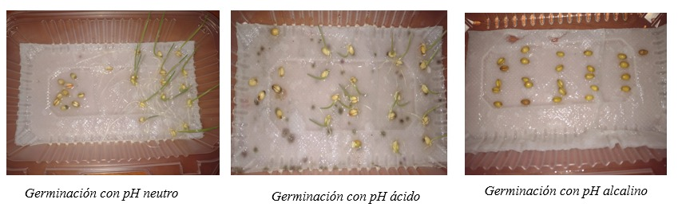

### 3.3.1 Porcentaje de germinación (GRP)

```r
av <- aov(grp ~ tratamiento, data = gsm)
anova(av)
## Analysis of Variance Table
##
## Response: grp
##             Df Sum Sq Mean Sq F value        Pr(>F)
## tratamiento  2  15247  7623.5  95.293 0.00000004319 ***
## Residuals   12    960    80.0
## ---
## Signif. codes:  0 '***' 0.001 '**' 0.01 '*' 0.05 '.' 0.1 ' ' 1

mc_grp <- ger_testcomp(aov = av
                       , comp = c("tratamiento")
                       , type = "snk"
                       )

mc_grp$table %>%
   kable(caption = "Comparación de la media del porcentaje de germinación")
```

Comparación de la media del porcentaje de germinación

| tratamiento | grp | std | r | ste | se | min | max | sig |
| --- | --- | --- | --- | --- | --- | --- | --- | --- |
| pH ácido | 66.4 | 9.208692 | 5 | 4.118252 | 4 | 52 | 76 | a |
| pH alcalino | 0.0 | 0.000000 | 5 | 0.000000 | 4 | 0 | 0 | b |
| pH neutro | 68.8 | 12.457929 | 5 | 5.571355 | 4 | 56 | 84 | a |

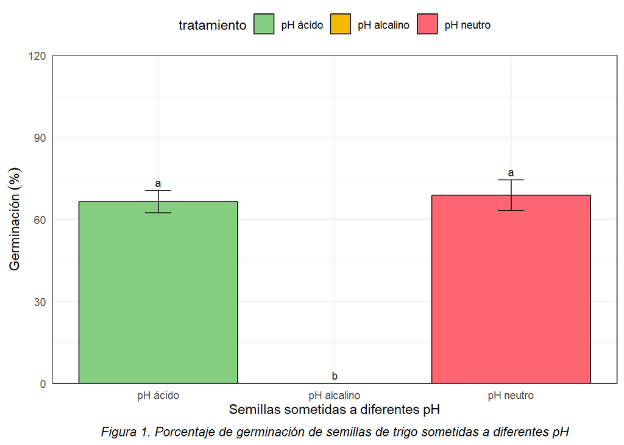

```r
grp <- mc_grp$table %>%
   fplot(data = .,
         type = "bar",
         x = "tratamiento",
         y = "grp",
         group = "tratamiento",
         ylimits = c(0, 120, 30),
         ylab = "Germinación ('%')",
         xlab = "Semillas sometidas a diferentes pH",
         error = "ste",
         sig = "sig",
         color = TRUE
   ) +
   labs(caption = "Figura 1. Porcentaje de germinación de semillas de trigo sometidas a diferentes pH") +
   theme(plot.caption = element_text(hjust = 0.5, size = 10, face = "italic"))
grp
```

### 3.3.2 Germinación en el tiempo (MGT)

```r
av <- aov(mgt ~ tratamiento, data = gsm)
anova(av)
## Analysis of Variance Table
##
## Response: mgt
##             Df  Sum Sq  Mean Sq F value  Pr(>F)
## tratamiento  1 0.13887 0.138873   9.937 0.01355 *
## Residuals    8 0.11180 0.013975
## ---
## Signif. codes:  0 '***' 0.001 '**' 0.01 '*' 0.05 '.' 0.1 ' ' 1


mc_mgt <- ger_testcomp(aov = av
                       , comp = c("tratamiento")
                       , type = "snk")

mc_mgt$table %>%
   kable(caption = "Comparación del tiempo medio de germinación")
```

Comparación del tiempo medio de germinación

| tratamiento | mgt | std | r | ste | se | min | max | sig |
| --- | --- | --- | --- | --- | --- | --- | --- | --- |
| pH ácido | 2.062525 | 0.0424373 | 5 | 0.0189785 | 0.0528684 | 2.0000 | 2.117647 | b |
| pH neutro | 2.298214 | 0.1617088 | 5 | 0.0723184 | 0.0528684 | 2.0625 | 2.500000 | a |

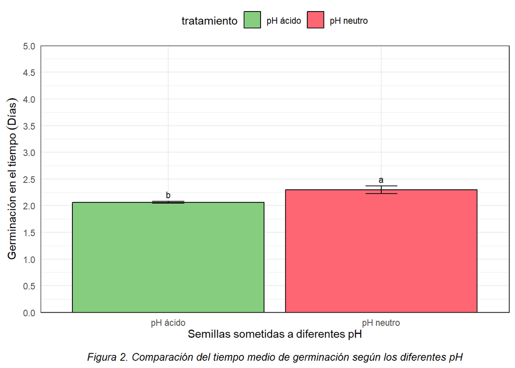

```r
mgt <- mc_mgt$table %>%
   fplot(data = .,
         type = "bar",
         x = "tratamiento",
         y = "mgt",
         group = "tratamiento",
         ylimits = c(0, 5, 0.5),
         ylab = "Germinación en el tiempo (Días)",
         xlab = "Semillas sometidas a diferentes pH",
         sig = "sig",
         error = "ste",
         color = TRUE
   ) +
   labs(caption = "Figura 2. Comparación del tiempo medio de germinación según los diferentes pH") +
   theme(plot.caption = element_text(hjust = 0.5, size = 10, face = "italic", margin = margin(t = 10)))

mgt
```

### 3.3.3 Análisis acumulativo de germinación

```r
git <- ger_intime(Factor = "tratamiento"
                  , SeedN = "seeds"
                  , evalName = "d"
                  , method = "percentage"
                  , data = fb
                  )

git %>%
   head(10) %>%
   kable(caption = "Acumulación de germinación en los diferentes pH")
```

Acumulación de germinación en los diferentes pH

| tratamiento | evaluation | mean | r | std | min | max | ste |
| --- | --- | --- | --- | --- | --- | --- | --- |
| pH ácido | 0 | 0.0 | 5 | 0.000000 | 0 | 0 | 0.000000 |
| pH alcalino | 0 | 0.0 | 5 | 0.000000 | 0 | 0 | 0.000000 |
| pH neutro | 0 | 0.0 | 5 | 0.000000 | 0 | 0 | 0.000000 |
| pH ácido | 1 | 0.0 | 5 | 0.000000 | 0 | 0 | 0.000000 |
| pH alcalino | 1 | 0.0 | 5 | 0.000000 | 0 | 0 | 0.000000 |
| pH neutro | 1 | 0.0 | 5 | 0.000000 | 0 | 0 | 0.000000 |
| pH ácido | 2 | 62.4 | 5 | 10.430724 | 48 | 76 | 4.664762 |
| pH alcalino | 2 | 0.0 | 5 | 0.000000 | 0 | 0 | 0.000000 |
| pH neutro | 2 | 55.2 | 5 | 8.671793 | 48 | 68 | 3.878144 |
| pH ácido | 3 | 66.4 | 5 | 9.208692 | 52 | 76 | 4.118252 |

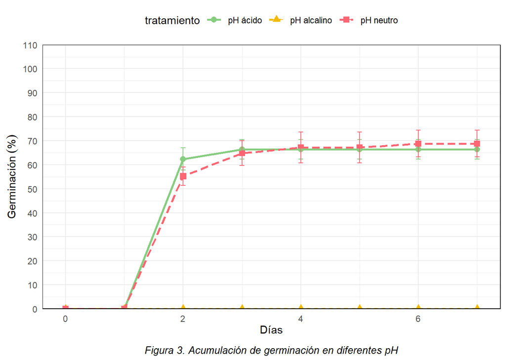

```r
tratamiento <- git %>%
   fplot(data = .,
         type = "line",
         x = "evaluation",
         y = "mean",
         group = "tratamiento",
         ylimits = c(0, 110, 10),
         ylab = "Germinación ('%')",
         xlab = "Días",
         glab = "tratamiento",
         color = TRUE,
         error = "ste"
   ) +
   labs(caption = "Figura 3. Acumulación de germinación en diferentes pH") +
   theme(plot.caption = element_text(hjust = 0.5, size = 10, face = "italic", margin = margin(t = 10)))

tratamiento
```

La curva de germinación acumulada mostró que la mayor parte de la germinación ocurrió en los primeros tres días para los tratamientos y ácido neutro, con valores estabilizándose cerca del 70%. Ambos tratamientos mostraron una dinámica de germinación rápida y muy similar, aunque con una leve ventaja en velocidad para el tratamiento ácido. Por otro lado, el tratamiento alcalino no presentó ningún porcentaje de germinación en todo el periodo evaluado, confirmando su efecto totalmente negativo sobre el proceso germinativo.

### 3.3.4 Índice de sincronización (SYN)

```r
av <- aov(syn ~ tratamiento, data = gsm)
anova(av)
## Analysis of Variance Table
##
## Response: syn
##             Df  Sum Sq  Mean Sq F value Pr(>F)
## tratamiento  1 0.09079 0.090790  5.5215 0.0467 *
## Residuals    8 0.13154 0.016443
## ---
## Signif. codes:  0 '***' 0.001 '**' 0.01 '*' 0.05 '.' 0.1 ' ' 1


mc_syn <- ger_testcomp(aov = av
                       , comp = "tratamiento"
                       , type = "snk"
                       )

mc_syn$table %>%
   kable(caption = "Índice de sincronización")
```

Índice de sincronización

| tratamiento | syn | std | r | ste | se | min | max | sig |
| --- | --- | --- | --- | --- | --- | --- | --- | --- |
| pH ácido | 0.8778909 | 0.0802268 | 5 | 0.0358785 | 0.0573462 | 0.7794118 | 1.000 | a |
| pH neutro | 0.6873231 | 0.1626331 | 5 | 0.0727317 | 0.0573462 | 0.4315789 | 0.875 | b |

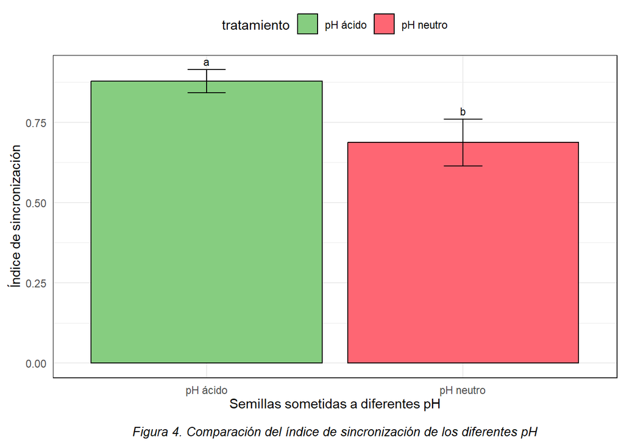

```r
syn <- mc_syn$table %>%
   fplot(data = .
       , type = "bar"
       , x = "tratamiento"
       , y = "syn"
       , group = "tratamiento"
       , ylab = "Índice de sincronización"
       , xlab = "Semillas sometidas a diferentes pH"
       , glab = "tratamiento"
       , sig = "sig"
       , error = "ste"
       , color = T
       ) +
   labs(caption = "Figura 4. Comparación del índice de sincronización de los diferentes pH") +
   theme(plot.caption = element_text(hjust = 0.5, size = 10, face = "italic", margin = margin(t = 10)))

syn
```

## 3.4 DISCUSIONES

El pH del medio mostró un efecto claro sobre la germinación de semillas de trigo (Triticum aestivum). Los tratamientos ácido y neutro alcanzaron porcentajes de germinación cercanos al 70 %, mientras que el pH alcalino inhibió completamente el proceso. Además, el tiempo medio de germinación fue menor bajo pH ácido (~2 días), indicando una germinación más rápida en comparación con el tratamiento neutro.

El índice de velocidad de germinación también fue mayor en el tratamiento ácido, lo que refleja una mayor eficiencia fisiológica en las primeras etapas. Del mismo modo, el índice de sincronización fue más alto en este tratamiento, evidenciando una germinación más agrupada en el tiempo. En contraste, el tratamiento alcalino no presentó germinación, por lo que estos índices fueron nulos.

Estos resultados coinciden con lo reportado por Neina (2019), quien indica que un pH ligeramente ácido mejora la disponibilidad de nutrientes y la actividad enzimática. También se alinean con Hussein et al. (2016) y Shaikh et al. (2021), quienes destacan que un ambiente ácido favorece la activación de enzimas como la α-amilasa, acelerando la germinación. Por el contrario, la alcalinidad puede causar toxicidad iónica (Liu et al., 2022), afectando la absorción de agua y la viabilidad de las semillas.

# 4 CONCLUSIONES

Las semillas de Triticum aestivum mostraron un porcentaje de germinación cercano al 70% bajo condiciones de pH neutro y ácido, mientras que en pH alcalino no germinaron. Esto indica que el pH del medio influye directamente en el éxito de la germinación, siendo el ambiente alcalino totalmente desfavorable.

El tiempo promedio de germinación fue más corto en el tratamiento ácido (aproximadamente 2 días), seguido por el neutro (poco más de 2 días). En el tratamiento alcalino no se registró germinación, por lo que no fue posible calcular este valor. Esto sugiere que un pH ligeramente ácido puede acelerar el proceso germinativo en trigo.

El índice de velocidad de germinación fue mayor en el tratamiento ácido, seguido del neutro, reflejando no solo una germinación más temprana sino también más uniforme. El tratamiento alcalino no registró germinación, por lo que su índice fue cero, confirmando su efecto negativo sobre la dinámica del proceso germinativo.

# 5 REFERENCIAS BIBLIOGRÁFICAS

- Bewley, JD, Bradford, KJ, Hilhorst, HWM y Nonogaki, H. (2013). Semillas: Fisiología del desarrollo, germinación y latencia (3.ª ed.). Springer. Cienciabit. (2019). Reacción de descomposición del bicarbonato de sodio. Experimento de química. – Cienciabit. https://cienciabit.com/wp51/blog/2019/05/30/reaccion-de-descomposicion-del-bicarbonato-de-sodio-experimento-de-quimica/
- FAO. (2021). El estado mundial de la agricultura y la alimentación 2021. Organización de las Naciones Unidas para la Alimentación y la Agricultura. ‌
- Hussein, MM, et al. (2016). Efecto de los niveles de pH en la germinación de las semillas y el crecimiento de las plántulas de maíz. Journal of Soil Sciences and Agricultural Engineering, 7(3), 197–204.
- Kumar, R., Singh, J. y Kaushik, P. (2021). Efecto del pH en la germinación de semillas y el crecimiento de plántulas: Una revisión. Journal of Plant Physiology and Biochemistry, 160, 20–28.
- Liu, D., Ma, Y., Rui, M., Lv, X., Chen, R., Chen, X. y Wang, Y. (2022). ¿Es el pH alto el factor clave del estrés alcalino en el crecimiento y la fisiología de las plantas? Un estudio de caso con plántulas de trigo (Triticum aestivum L.). Agronomía, 12(8), 1820. https://doi.org/10.3390/agronomy12081820
- Navarrete, D. (2018). Ácidos y bases. https://fq.iespm.es/documentos/diego_navarrete/2_quimica/7.pdf
- Neina, D. (2019). El papel del pH del suelo en la nutrición de las plantas y la remediación del suelo. Ciencias del suelo aplicadas y ambientales, 2019, 1–9. https://doi.org/10.1155/2019/5794869
- Shaikh, SA, et al. (2021). Efecto de la salinidad y el pH sobre la germinación de semillas de cereales. Revista internacional de estudios de botánica, 6(2), 240–245.
- Velázquez-Barrón, MDL Á., & Fuentes-Dávila, G. (2009). Germinación de la semilla de cuatro variedades de trigo (Triticum spp. L.). In vitro. BIOtecnia, 11(3), 12. https://doi.org/10.18633/bt.v11i3.70
- Wang, R., Yang, Y., Wang, X., Li, J., Gao, Y., Huang, H., Zhou, Z., Wang, P. y Zhao, L. (2025). Respuesta de la germinación de semillas y el crecimiento de plántulas de raigrás perenne (Lolium perenne L.) a la sequía, la salinidad y el pH en regiones kársticas. Scientific Reports, 15(1), 16874. https://doi.org/10.1038/s41598-025-01539-5